# Practical: The EZ diffusion model

The code blocks below can be copy pasted onto the R command line.

Reference: Wagenmakers, E.-J., van der Maas, H. L. J. & Grasman, R. P. P. P. (2007). An EZ-diffusion model for response time and accuracy. Psychonomic Bulletin & Review, 14, 3-22

First, clear your workspace and load the EZ formula:

```r
rm(list = ls())

get.vaTer = function(Pc, VRT, MRT, s=.1)
{
    s2 = s^2
    # The default value for the scaling parameter s equals .1

    if (any(Pc == 0))
        cat("Oops, Pc == 0!\n")
    if (any(Pc == 0.5))
        cat("Oops, Pc == .5!\n")
    if (any(Pc == 1))
        cat("Oops, Pc == 1!\n")
    # If Pc equals 0, .5, or 1, the method will not work, and
    # an edge-correction is required.

    L = qlogis(Pc)
    # The function "qlogis" calculates the logit.
    x = L*(L*Pc^2 - L*Pc + Pc - 0.5)/VRT
    v = sign(Pc-0.5)*s*x^(1/4)
    # This gives drift rate.

    a = s2*qlogis(Pc)/v
    # This gives boundary separation.

    y   = -v*a/s2
    MDT = (a/(2*v))*(1-exp(y))/(1+exp(y))
    Ter = MRT-MDT
    # This gives nondecision time.

    return(list(v=v, a=a, Ter=Ter))
}
```

## Assignment 1

What are the differences between the EZ diffusion model and the “full” Ratcliff diffusion model?

## Assignment 2

Assume you have a data set with the following properties

```r
Pc <- .9 # the proportion correct responses
MRT <- 100 # the mean response time
VRT <- 1000 # the variance in the response time distribution
```

the EZ diffusion parameters are provided by

```r
get.vaTer(Pc, VRT, MRT)
```

```
## $v
## [1] 0.01451913
##
## $a
## [1] 1.513331
##
## $Ter
## [1] 58.30796
```

with v: drift rate; a: boundary separation (threshold); Ter: non-decision time (“T (perceptual) encoding & response (execution)”).

1. How do the parameters change if the proportion of correct responses changes?
2. How do the parameters change if the mean response time changes?
3. How do the parameters change if the variance in the response times changes?

Make a graph to illustrate the effects of behavioral changes on parameters.

## Assignment 3

you have the following hypothetical data set:

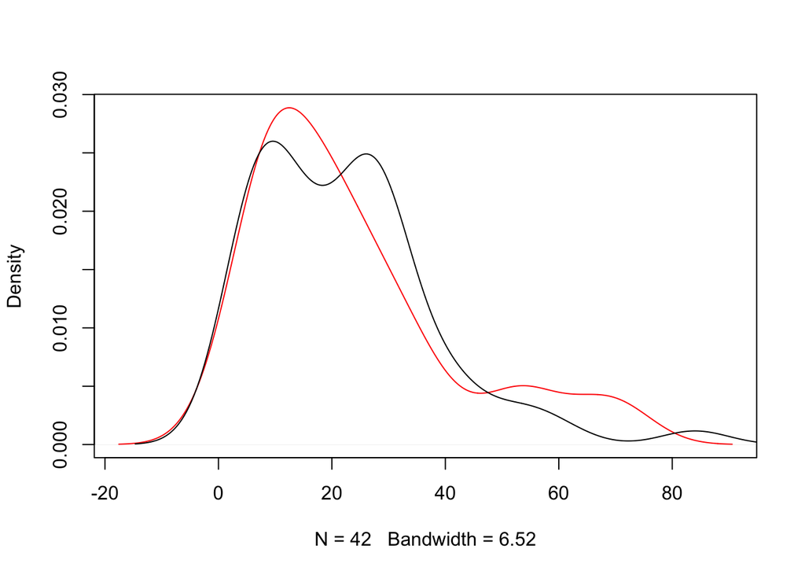

```r
dat <- read.csv("data1.txt", header=FALSE)
correct <- dat[[1]]
rt <- dat[[2]]
plot(density(rt[correct==FALSE]), col=2, main="")
lines(density(rt[correct==TRUE]), col=1)
```

Can you compute the EZ diffusion parameters (follow the steps below)?

1. Inspect the data for suitability
2. Compute the relevant properties of the data
3. Compute the EZ diffusion parameters as above

## Assignment 4

you have the following hypothetical data set:

```r
dat <- read.csv("data2.txt", header=FALSE)
correct <- dat[[1]]
rt <- dat[[2]]
```

1. Compute the EZ diffusion parameters
2. Do these parameters make sense? If no, why not?

## Assignment 5

you have the following data set, taken from a lexical decision experiment by Keuleers et al (2010):

```r
load("brysbaert.Rdata")
```

The data frame is called `d`, and the column names are (I think) self explanatory.

1. Compute the EZ diffusion parameters per participant and condition (ie, word or nonword, the wnw column)
2. Can you interpret the parameters? In other words, which (if any) of the parameters explains the difference between words and non-words?
3. Do these results make theoretical sense? Why (not)?

## Assignment 6

The following two functions are needed. The first function concerns the joint density function of the diffusion model. The second function concerns a function that simulates data (rts and accuracies) according to the diffusion model.

```r
ddiff = function(t,x,a,v,Ter) {
  # t: reaction time
  # x: accuracies
  #a: boundary sep; v: drift rate; ter: non-decision time
  sh1=sh2=1
  sh3=0
  eps=1e-15
  k=1
  while(abs(sh1-sh2) > eps | abs(sh1-sh3) > eps){
    K=k*sin(.5*pi*k)*exp(-(pi^2*k^2)/(2*a^2)*(t-Ter))
    sh1=sh2
    sh2=sh3
    sh3=sh3+pi/a^2*exp(a*v*(x-.5)-v^2/2*(t-Ter))*K
    k=k+1
    }
  return(sh3)
  }

sim.diff = function(N,a,v,ter) {
  #a: boundary sep; v: drift rate; ter: non-decision time
  si=1 #scaling factor
  M=pi*si^2/a^2 * (exp(a*v/(2*si^2))+exp(-a*v/(2*si^2))) * 1/ (v^2/(2*si^2)+pi^2*si^2 / (2*a^2))
  lmb = v^2/(2*si^2) +pi^2*si^2/(2*a^2)
  eps=1e-15
  ou=c()
  rej=0
  while(length(ou)<N){
    w=runif(1); u=runif(1);
    FF=pi^2*si^4 * 1/(pi^2*si^4+v^2*a^2)
    sh1=1
    sh2=0
    sh3=0
    i=0
    while(abs(sh1-sh2)>eps | abs(sh2-sh3)>eps){
      sh1=sh2
      sh2=sh3
      i=i+1
      sh3= sh2 + (2*i+1)*(-1)^i*(1-u)^(FF*(2*i+1)^2)
      }
    eval=1+(1-u)^-FF * sh3
    if(w<=eval) ou=c(ou,1/lmb*abs(log(1-u)))
    else rej=rej+1
    }
  p=exp(a*v)/(1+exp(a*v))
  chance=runif(N)
  (p>chance)*1->x
  return(list(x=x,rt=ou+ter))
}
```

```r
set.seed(1310)
a=2
v=1
N=500
ter=.75
data=sim.diff(N,a,v,ter)
rt=data$rt
x=data$x
```

2. Using the function ddiff above, determine the log-likelihood of the data for a=1, v=2, and ter=0.5. You should obtain -2607.498
3. Use R’s build-in function `optim` to maximize the log-likelihood of the unkown parameters `a`, `v`, and `Ter`. See `?optim` for more details. In optim it is possible to provide upper and lower bounds, use `c(0,Inf)` for `a`, use `c(-Inf, Inf)` for `v`, and `c(0,min(rt)-.01)` for `Ter`. To enable specification of boundaries, you need to use `method="L-BFGS-B"`. In addition you need to provide the following argument to optim: `control=list(fnscale=-1)` because otherwise optim will try to minimize the likelihood. Make sure that you use the data generated above (i.e., using `set.seed(1310)`). The value of the likelihood function at its maximum should be -480.5922. As starting values v=1, a=1, and Ter=0.25 worked for me.
4. Estimate the EZ-diffusion parameters using the function get.vaTer(). Make sure that you use s=1 in this function (the default is s=.1 which puts the parameters on a different scale). Compare these EZ-parameter estimates to the ones you obtained using maximum likelihood. What do you think of the similarity/differences?

## Assignment 7

Simulate data using the following code:

```r
set.seed(1310)
a=2
v=1
N=500
ter=.75
data=sim.diff(N,a,v,ter)
rt1=data$rt
x1=data$x
a=1
data=sim.diff(N,a,v,ter)
rt2=data$rt
x2=data$x
rt=c(rt1,rt2)
x=c(x1,x2)
```

i.e., this code simulates data for 500 trials administered under an accuracy instruction (‘answer as accurate as possible’) and 500 trials administered under a speed instruction (‘answer as fast as possible’).

1. Which parameter is simulated to be affected by the manipulation?

We now introduce a new parameter $\Delta$a. This parameter models the difference between the a in the second condition as compared to the first condition. Thus it holds that

**Accuracy condition (first 500 trials of vector rt)**

- boundary separation = a
- drift rate = v
- non-decision time = Ter

**Speed condition (second 500 trials of vector rt)**

- boundary separation = a + $\Delta$a
- drift rate = v
- non-decision time = Ter

i.e., we have four parameters: a, $\Delta$a, v, Ter.

2. In the data as simulated above (using `set.seed(1310)`), what is the likelihood of the data for a=2, $\Delta$a=.5, v=1, and Ter=.5? You should obtain -1125.825.
3. Optimize the likelihood function for the unknown parameters (a, $\Delta$a, v, Ter). Use the same settings as before. For $\Delta$a, you can use `c(-Inf, Inf)` as boundaries. Make sure that you use the data generated above (i.e., using `set.seed(1310)`). The value of the likelihood function at its maximum should be -441.9329. As starting values a=1, $\Delta$a=.1, v=1, and Ter=0.5 worked for me.
4. What do you think of the recovery of the true parameter values (i.e., are the parameter values that are used to create the data satisfactorily recovery in the parameter estimates)?
5. Do the above, but now for v. That is, simulate 500 trials with v=1, a=1, and Ter=.75 and 500 trials with v=2, a=1, and Ter=.75. Fit a model with an effect on v (i.e., introduce $\Delta$v similarly as above in case of a). If you use `set.seed(1310)` again in data generation, the maximum of your likelihood function should be 179.8556.